# Métodos e Ferramentas para Análise de Investimentos

Empreendedorismo Tecnológico e Desenvolvimento Territorial · Aula 13

Prof. Dr. Luiz Diego Vidal Santos

## Unidade III Visão Geral da Aula

**01 · Fluxo de Caixa:** Valor do dinheiro no tempo e construção do Fluxo de Caixa Livre.

**02 · Custo de Capital:** Custo de oportunidade via TMA, CAPM e WACC.

**03 · Critérios Determinísticos:** VPL, TIR, MTIR, VAUE e *Payback*.

**04 · Conflitos de Decisão:** Projetos mutuamente excludentes, vidas desiguais e racionamento.

**05 · Risco e Incerteza:** Análise de sensibilidade, cenários e simulação de Monte Carlo.

Objetivo da Aula Rigor quantitativo na decisão

Capacitar o(a) discente a estruturar fluxos de caixa de projetos, estimar taxas de desconto (TMA/WACC) e aplicar os principais **métodos quantitativos de análise de investimentos** (VPL, TIR, MTIR, *Payback* e análise de risco) em empreendimentos tecnológicos e territoriais.

FCFF & WACC VPL & TIR Monte Carlo

# Fluxo de Caixa e Custo de Capital

## Método Antes das Fórmulas: Por Que R$ 100 Hoje Valem Mais que Amanhã?

Fundamento 01 O Valor do Dinheiro no Tempo

- Receber **R$ 100 hoje** permite aplicar esse recurso ou resolver uma necessidade imediata; esperar 3 anos traz inflação, risco e perda de oportunidades.
- Ao avaliar um projeto territorial (como uma agroindústria cooperativa ou planta de bioinsumos), não basta somar quanto entra no caixa ao longo dos anos.
- É preciso **trazer os valores futuros para o presente** usando uma taxa de desconto mínima aceitável (**TMA**).

Fundamento 02 Caixa Não É Lucro Contábil

- Uma empresa pode registrar lucro no papel e quebrar por falta de dinheiro em caixa para pagar fornecedores ou comprar equipamentos.
- Na análise de investimentos, trabalhamos com **Fluxo de Caixa**: o dinheiro que efetivamente entra e sai a cada período, já descontando investimentos em máquinas (**CAPEX**) e capital de giro (**CGL**).

**Regra de ouro:** trabalhar apenas com **fluxos de caixa incrementais** e excluir **custos afundados** (*sunk costs*).

## Método Fluxo de Caixa Livre e Taxa de Desconto

**Fluxo de Caixa Livre da Firma (FCFF)**

$$\text{FCFF} = \text{EBIT} \cdot (1 - T) + \text{Depreciação} - \text{CAPEX} - \Delta \text{CGL}$$

Consistência Monetária Taxas Nominais vs. Reais

- Se o fluxo está em moeda constante (sem inflação), descontar pela taxa real; se inclui inflação, usar taxa nominal.
- **Equação de Fisher:** $1 + i_{\text{nom}} = (1 + i_{\text{real}})(1 + \pi)$.

**CAPM e WACC (Assaf Neto, 2021)**

$$K_e = R_f + \beta \cdot (R_m - R_f) + R_{\text{país}}$$

$$\text{WACC} = K_e \cdot \frac{E}{D + E} + K_d \cdot (1 - T) \cdot \frac{D}{D + E}$$

Projetos Territoriais Taxa Social de Desconto

Projetos públicos ou de impacto territorial frequentemente utilizam uma **Taxa Social de Desconto** complementar à TMA privada.

# Critérios de Decisão de Investimentos

## Decisão VPL, TIR, MTIR, VAUE e *Payback*

**Valor Presente Líquido (VPL)**

$$\text{VPL} = -I_0 + \sum_{t=1}^{n} \frac{FC_t}{(1 + i)^t}$$

*Aceitar se $\text{VPL} > 0$.* Mede a criação absoluta de riqueza na data zero.

Taxas de Retorno TIR e MTIR

- **TIR:** taxa $i^*$ que zera o VPL ($\text{VPL}(i^*) = 0$). *Aceitar se $\text{TIR} > \text{TMA}$.*
- **MTIR (TIR Modificada):** corrige a premissa irrealista de reinvestimento à própria TIR, adotando a TMA para reinvestir os fluxos intermediários.

Tempo e Escala *Payback* e VAUE

- *Payback* Simples vs. Descontado: mede o tempo de recuperação do investimento; o simples ignora o valor do dinheiro no tempo e ambos ignoram fluxos após o corte.
- **VAUE (Valor Anual Uniforme Equivalente):** ideal para comparar projetos com **vidas úteis diferentes**.

Armadilhas da TIR Quando há Conflito, Prevalece o VPL

Múltiplas TIRs em fluxos não convencionais (mudanças de sinal) e conflito de escala em projetos mutuamente excludentes $\rightarrow$ **em caso de conflito, prevalece o VPL**.

## Decisão Gráfico Didático: Perfil do VPL × Taxa de Desconto

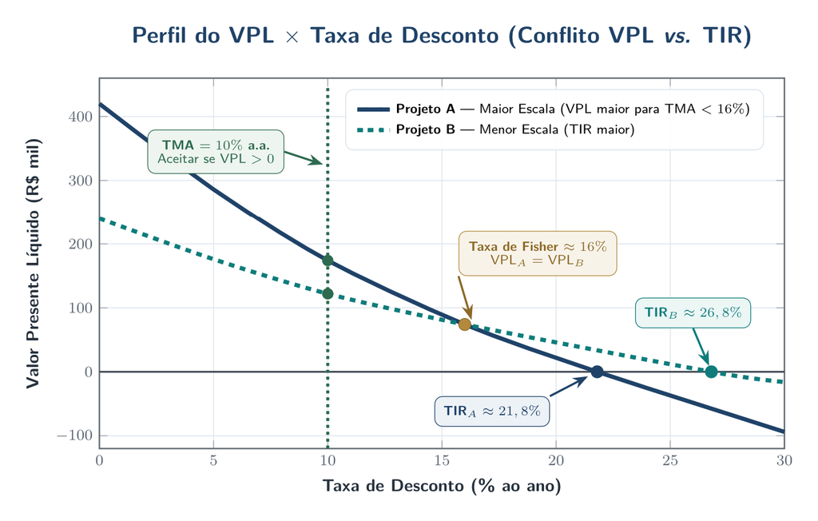

Curva do VPL em função da taxa de desconto para projetos mutuamente excludentes (conflito VPL vs. TIR abaixo da taxa de interseção de Fisher).

Perfil do VPL em função da taxa de desconto Conflito VPL vs. TIR para projetos mutuamente excludentes abaixo da taxa de interseção de Fisher

Abaixo da taxa de interseção de Fisher, TIR e VPL ordenam os projetos de forma oposta; o **VPL** decide corretamente por medir o ganho líquido em valor presente.

# Análise de Risco e Oficina em Planilha

## Síntese Sensibilidade, Cenários e Prática em Sala

**01 · Análise de Sensibilidade:** varia uma variável-chave por vez (ex.: preço $-15\%$, CAPEX $+20\%$) para identificar o ponto crítico (*break-even* financeiro).

**02 · Análise de Cenários:** constrói combinações coerentes de variáveis (Otimista, Base, Pessimista).

**03 · Simulação de Monte Carlo:** atribui distribuições de probabilidade às entradas incertas e estima a distribuição do VPL ($P(\text{VPL} > 0)$).

Oficina Prática · 60 min Exercício em Planilha

Dado um projeto agroindustrial/tecnológico com investimento inicial de **R$ 500 mil** e horizonte de **5 anos**, calcular **FCFF, WACC, VPL, TIR, MTIR e Payback Descontado**, e testar sensibilidade a uma queda de **15% na receita**.

Próxima Aula Leituras Recomendadas

- **DAMODARAN, A.** *Avaliação de investimentos* (Caps. sobre FCD e Múltiplos) e *The dark side of valuation* (Cap. sobre empresas jovens).